# Bayesian Stats, Meeting 2

Adam Clark

2025-10-27

## Introduction

Today, we’re going to cover a (very brief) recap of linear regression in R, and then move on to a motivation for, and application of, mixed-effects models.

Mixed-effects models, as they are commonly implemented in R, take advantage of the methods we’ve been discussing in order to “group” uncertainty across different levels of organisation. I’ll include some more detail on this below, but you can basically think of these models as a series of Gaussian priors that we use to structure residual variance. If you want a really detailed walk-through for these methods, the book [here](https://link.springer.com/book/10.1007/b98882) is a good place to start.

## Ordinary Least Squares (OLS) Example

Let’s start with a very simple relationship between two variables: plant diversity, and plot-level biomass. The data below are “fake” (and I’ll include the scripts that I use to create them), but this is a very general pattern that we often see in biodiversity experiments.

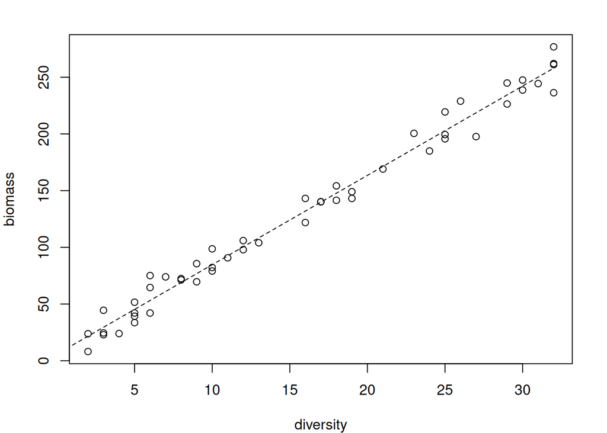

```r
# OLS example
set.seed(231011) # seed for analyses
intercepts = 5 # y-intercept
slopes = 8 # slope
error = 10 # residual error

# make fake data for 50 plots
bdat = data.frame(plot = 1:50,
                  diversity = sample(1:32, 50, rep = TRUE), # randomly select richness between 1 and 32
                  biomass = NA)

# generate random biomass data
bdat$biomass=intercepts + slopes*bdat$diversity + rnorm(nrow(bdat), 0, error)

# plot
par(mar=c(4,4,2,2))
plot(biomass~diversity, data = bdat)

# fit a regression
mod_ols = lm(biomass~diversity, data = bdat)

# add regression line to plot
curve(coef(mod_ols)[1]+coef(mod_ols)[2]*x, from = 1, to = 32, add = TRUE, lty = 2)
```

```r
# get summary of regression
summary(mod_ols)
```

```
##
## Call:
## lm(formula = biomass ~ diversity, data = bdat)
##
## Residuals:
##     Min      1Q  Median      3Q     Max
## -21.667  -6.570  -2.351   6.468  21.947
##
## Coefficients:
##             Estimate Std. Error t value Pr(>|t|)
## (Intercept)   5.8816     2.7670   2.126   0.0387 *
## diversity     7.8794     0.1487  52.971   <2e-16 ***
## ---
## Signif. codes:  0 '***' 0.001 '**' 0.01 '*' 0.05 '.' 0.1 ' ' 1
##
## Residual standard error: 10.43 on 48 degrees of freedom
## Multiple R-squared:  0.9832, Adjusted R-squared:  0.9828
## F-statistic:  2806 on 1 and 48 DF,  p-value: < 2.2e-16
```

## Multiple Regression

So far so good. Now, let’s try a case where the y-intercept varies across different subsets of data. We’ll call each of these subsets a “block”. To fit this case correctly, we’ll need to fit a multiple regression, with block as a covariate.

```r
# Multiple regression example
set.seed(231011) # seed for analyses
slopes = 8 # slope
error = 10 # residual error
n_blocks = 10 # number of blocks
intercepts = sort(rnorm(n_blocks, mean = 100, sd = 80)) # y-intercepts for each block

# make fake data for 50 plots
bdat = data.frame(plot = 1:50,
                  block = rep(1:n_blocks, each = 50),
                  diversity = sample(1:32, 50*n_blocks, rep = TRUE), # randomly select richness between 1 and 32
                  biomass = NA)

# generate random biomass data
bdat$biomass=intercepts[bdat$block] + slopes*bdat$diversity + rnorm(nrow(bdat), 0, error)

# plot
par(mar=c(4,4,2,2))
plot(biomass~diversity, data = bdat, col = rainbow(n_blocks)[bdat$block])

# fit a regression
mod_mreg = lm(biomass~-1+as.factor(block) + diversity, data = bdat)
# NOTE: think about what this "-1" is doing. Try fitting the model with and without it, and looking at the "summary".

# add regression line to plot
for(i in 1:n_blocks) {
curve(coef(mod_mreg)[i]+coef(mod_mreg)[n_blocks+1]*x, from = 1, to = 32, add = TRUE, lty = 2, col = rainbow(n_blocks)[i])
}

# get summary of regression
summary(mod_mreg)
```

```
##
## Call:
## lm(formula = biomass ~ -1 + as.factor(block) + diversity, data = bdat)
##
## Residuals:
##      Min       1Q   Median       3Q      Max
## -26.8728  -6.5879  -0.1268   6.2607  29.6419
##
## Coefficients:
##                     Estimate Std. Error t value Pr(>|t|)
## as.factor(block)1  -31.57032    1.56299 -20.199   <2e-16 ***
## as.factor(block)2   -2.27415    1.56900  -1.449    0.148
## as.factor(block)3   47.57059    1.52503  31.193   <2e-16 ***
## as.factor(block)4   52.80142    1.55388  33.980   <2e-16 ***
## as.factor(block)5   90.76112    1.52545  59.498   <2e-16 ***
## as.factor(block)6   94.76976    1.54938  61.166   <2e-16 ***
## as.factor(block)7  115.81990    1.57508  73.533   <2e-16 ***
## as.factor(block)8  119.01614    1.56807  75.900   <2e-16 ***
## as.factor(block)9  182.43004    1.59520 114.362   <2e-16 ***
## as.factor(block)10 187.17732    1.63696 114.345   <2e-16 ***
## diversity            7.98039    0.04644 171.837   <2e-16 ***
## ---
## Signif. codes:  0 '***' 0.001 '**' 0.01 '*' 0.05 '.' 0.1 ' ' 1
##
## Residual standard error: 9.603 on 489 degrees of freedom
## Multiple R-squared:  0.9985, Adjusted R-squared:  0.9984
## F-statistic: 2.911e+04 on 11 and 489 DF,  p-value: < 2.2e-16
```

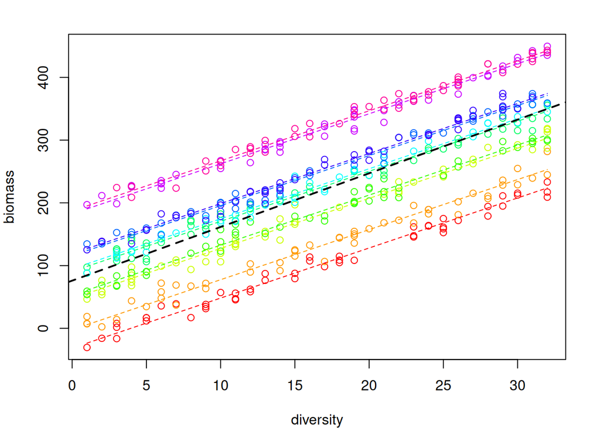

```r
# compare to a model without the intercept term
mod_mreg_mean = lm(biomass~diversity, data = bdat)
abline(mod_mreg_mean, lty = 2, col = "black", lwd = 2)
```

```r
summary(mod_mreg_mean)
```

```
##
## Call:
## lm(formula = biomass ~ diversity, data = bdat)
##
## Residuals:
##      Min       1Q   Median       3Q      Max
## -140.759  -41.892    8.061   38.894  122.669
##
## Coefficients:
##             Estimate Std. Error t value Pr(>|t|)
## (Intercept)  75.9951     6.2696   12.12   <2e-16 ***
## diversity     8.5566     0.3268   26.18   <2e-16 ***
## ---
## Signif. codes:  0 '***' 0.001 '**' 0.01 '*' 0.05 '.' 0.1 ' ' 1
##
## Residual standard error: 68.27 on 498 degrees of freedom
## Multiple R-squared:  0.5792, Adjusted R-squared:  0.5784
## F-statistic: 685.5 on 1 and 498 DF,  p-value: < 2.2e-16
```

## Simple mixed effects model (random intercepts)

Alright - it looks like accounting for the different intercepts among blocks helps us better account for observed variability in the data.

But, let’s now try another case, where some of the data are missing. Let’s pretend that we only have data from 1 plot from each block. What happens now?

```r
# remove data from block 6
bdat_small = bdat[bdat$plot == 1,]

# try to fit a model...
mod_mreg2 = lm(biomass~-1+as.factor(block) + diversity, data = bdat_small)

# get summary of regression
summary(mod_mreg2)
```

```
##
## Call:
## lm(formula = biomass ~ -1 + as.factor(block) + diversity, data = bdat_small)
##
## Residuals:
## ALL 10 residuals are 0: no residual degrees of freedom!
##
## Coefficients: (1 not defined because of singularities)
##                    Estimate Std. Error t value Pr(>|t|)
## as.factor(block)1     58.34        NaN     NaN      NaN
## as.factor(block)2    215.32        NaN     NaN      NaN
## as.factor(block)3    169.19        NaN     NaN      NaN
## as.factor(block)4    179.29        NaN     NaN      NaN
## as.factor(block)5    196.73        NaN     NaN      NaN
## as.factor(block)6    186.33        NaN     NaN      NaN
## as.factor(block)7    308.58        NaN     NaN      NaN
## as.factor(block)8    236.99        NaN     NaN      NaN
## as.factor(block)9    225.39        NaN     NaN      NaN
## as.factor(block)10   407.64        NaN     NaN      NaN
## diversity                NA         NA      NA       NA
##
## Residual standard error: NaN on 0 degrees of freedom
## Multiple R-squared:      1,  Adjusted R-squared:    NaN
## F-statistic:   NaN on 10 and 0 DF,  p-value: NA
```

Uhoh - looks like we are getting errors. This is because we don’t have enough data in order to fit a linear model to most of the sites.

Instead, we can try fitting a “mixed effects” model. These models allow us to “bundle” uncertainty across plots. Let’s try running the code first, and then walk through that the code actually means.

```r
require(nlme) # load nlme package
mod_mixef1 = lme(biomass~diversity, random = ~1|block, data = bdat_small)

summary(mod_mixef1)
```

```
## Linear mixed-effects model fit by REML
##   Data: bdat_small
##        AIC      BIC    logLik
##   108.8587 109.1765 -50.42937
##
## Random effects:
##  Formula: ~1 | block
##         (Intercept) Residual
## StdDev:    72.45245 27.16973
##
## Fixed effects:  biomass ~ diversity
##                Value Std.Error DF  t-value p-value
## (Intercept) 98.81271  60.90552  8 1.622393  0.1434
## diversity    7.20281   3.35987  8 2.143773  0.0644
##  Correlation:
##           (Intr)
## diversity -0.916
##
## Standardized Within-Group Residuals:
##         Min          Q1         Med          Q3         Max
## -0.57588390 -0.18558085  0.02852148  0.18427909  0.45351899
##
## Number of Observations: 10
## Number of Groups: 10
```

The bottom part of the output tells us more or less the same thing that we would have gotten from the call `lm(biomass~diversity)` (i.e. a single slope and a single intercept estimate).

The top part tells us something about how variance was grouped in the model. We can look at this output more directly using:

```r
VarCorr(mod_mixef1)
```

```
## block = pdLogChol(1)
##             Variance  StdDev
## (Intercept) 5249.3577 72.45245
## Residual     738.1945 27.16973
```

The residual intercept is just the unexplained variation (for larger sample sizes, this should match the “error” term above). More interestingly, note that the standard deviation across intercepts roughly matches the standard deviation of the intercept values for each block:

```r
sd(intercepts)
```

```
## [1] 70.85151
```

This is the magic prior being used “under the hood” in this analysis. Because we included the argument `random = ~1|block)`, R assumes that the intercept term (`1`) is normally distributed and varies across blocks. We can even access estiamates for these different intercept terms, and use these estimates to draw regression lines:

```r
# plot
par(mar=c(4,4,2,2))
plot(biomass~diversity, data = bdat_small, col = rainbow(n_blocks)[bdat_small$block])

# fit a regression
print(ranef(mod_mixef1))
```

```
##     (Intercept)
## 1  -111.2642685
## 2   -68.3582850
## 3   -33.0225038
## 4   -36.7996298
## 5    10.0677729
## 6     0.9532739
## 7    38.6646784
## 8    26.4213231
## 9    85.7150142
## 10   87.6226246
```

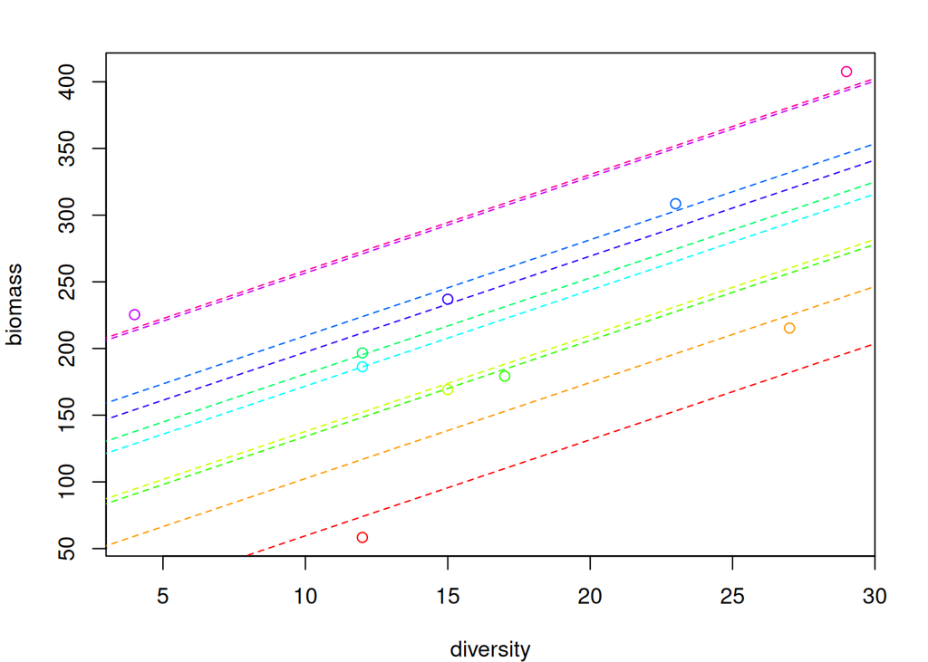

```r
# add regression line to plot
for(i in 1:n_blocks) {
curve(fixef(mod_mixef1)[1]+ranef(mod_mixef1)[i,1] + fixef(mod_mixef1)[2]*x, from = 1, to = 32, add = TRUE, lty = 2, col = rainbow(n_blocks)[i])
}
```

We can even compare these estimates to the full dataset, and show that they do a pretty good job of estimating block-level values:

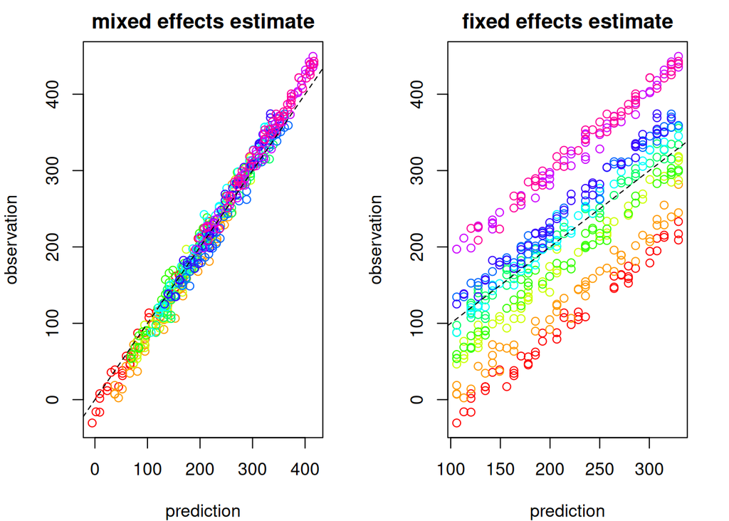

```r
par(mar = c(4,4,2,2), mfrow = c(1,2))
pred = predict(mod_mixef1, newdata = bdat)
plot(pred, bdat$biomass, xlab = "prediction", ylab = "observation", col = rainbow(n_blocks)[bdat$block], main = "mixed effects estimate")

abline(a=0, b=1, lty =2) # add 1-1 line


# compare to fit from "simple" model
mod_ols_simple = lm(biomass ~ diversity, data = bdat_small)
pred2 = predict(mod_ols_simple, newdata = bdat)
plot(pred2, bdat$biomass, xlab = "prediction", ylab = "observation", col = rainbow(n_blocks)[bdat$block], main = "fixed effects estimate")

abline(a=0, b=1, lty =2) # add 1-1 line
```

Notice that the observed vs. predicted plot shows a much tighter relationship for the cases with the “random” intercept. We’ve managed to successfully “borrow” statistical power across replicates!

### Note on interpreting mixed effects models

Technically, all “mixed effects” models implemented using common packages such as `nlme` or `lmer` in R carry out three independent, but mutually supporting, actions: 1) Estimates paramter values for each level of the model, BASED ON THE ASSUMPTION OF A GAUSSIAN PRIOR. 2) Accounts for autocorrelation among residuals (“pseudoreplication”). 2) Adjusts the degrees of freedom based on observation number and random effect structure, to generate a p-value.

Importantly, the resulting parameter estimates are no longer “BLUE”s (“best linear unbiased estimate”). Instead, they are “BLUP”s (“best linear unbiased predictors). That is, unlike OLS, where parameter estimates can (in some cases) be though of as estimates of the causal effect of variables on one another, mixed effect models focus on *predicting outcomes* - thus, paramter estimates can be (and often are) biased. E.g. for most analyses of experimental data, the BLUP estimate represents a conservative”minimum” effect size for the treatment in question treatment.

Note that some people feel very strongly that you should never model a variable as “random” if you have fewer than 6 or so replicates within a level (e.g. fewer than 6 plots per subplot). In general, models behave just fine with fewer replicates, but as this number gets smaller, it gets harder to fit your model, and the estimates will become less accurate.

Finally, in case you are wondering what the “~” symbol is for - this is just an oddity of the R language that is necessary for defining a function (which is what is being done under the hood for the fixed and random effects parts of the models we are fitting). These will always need to be there, but we can pretty much ignore them.

### Note on general lingo

Usually, we talk about model “effect sizes”, “p-values”, and “goodness of fit” (e.g. R-squared) as the three most important summary statistics of a regression. These represent, respectively: (1) our estimate of the relative change of a variable relative to other variables; (2) our relative confidence in our estimate of that variable relative to the null hypothesis that there is no relationship (though this interpretation is a bit controversial); and (3) how well model predictions represent the true states of the system. All three of these points can optimized for independently, and all three are important for interpreting a model.